# Data Analysis and Machine Learning

## Assessment 01

An important application of data science for healthcare is the prediction of possible cardiovascular disease without the need for invasive diagnostic procedures. Therefore, machine learning tools which can use information which is easy to measure to make accurate predictions of patient's risk of disease are becoming increasingly sought after.

You will be provided a data file containing a list of features about individual patients (**X**), and a second file containing two targets (**y**). Your task is to build two machine-learning models:

- a **classification model for predicting whether a patient has a high or low risk of cardiovascular disease**; the labels which contain this information are in the column `risk` of the variable `y`; high risk patients are assigned class 1, and low risk patients class 0.
- a **regression model for predicting the patient's maximum heart rate**; the labels which contain this information are in the column `max_heart_rate` of the variable `y`.

The full dataset contains 1189 examples. Each patient is described by a feature vector of 9 values, some of which are continuous and some of which are categorical. There are 2 target values to predict: `risk`, which contains class labels 1 and 0, and `max_heart_rate`, which contains a continuous target variable. A train/test (0.9/0.1) split has already been carried out and you only have access to the training dataset (containing 1070 examples). The testing dataset (containing the remaining 119 examples) is hidden - **you are not going to receive a copy of this.**

The data you need are provided in two .csv files in this part of the VLE:

- `x_train.csv`, containing 1070 examples with 9 features each (**X**).
- `y_train.csv`, containing 1070 examples with 2 targets each (**y**).

If you cannot get code to work, comment it out and write comments about what you are trying to do and how it fails. All code should generally be commented where appropriate as good practice dictates. When you have finished, use the option on the File menu to download this notebook as in .ipynb format and upload it to the submission point on the VLE. The criteria which will be used to mark your work are described in the [marking matrix](https://docs.google.com/document/d/1Gi3E3-DTsa9a7RFqKirvswaDw_mytXNDoF8Iy6YA3Lw/edit?tab=t.0#heading=h.b205rwm7jf5r).

Before you start, run the cell below (click the ▸ icon) to import the `numpy` and `matplotlib.pyplot` libraries:

```python
import numpy as np
import matplotlib.pyplot as plt
import pandas as pd
import seaborn as sns
from sklearn.preprocessing import RobustScaler
from sklearn.preprocessing import OneHotEncoder
from sklearn.impute import KNNImputer
from sklearn.compose import ColumnTransformer
from sklearn.preprocessing import OrdinalEncoder
from sklearn.model_selection import train_test_split
from sklearn.ensemble import RandomForestClassifier
from sklearn.feature_selection import SequentialFeatureSelector
from sklearn.linear_model import LogisticRegression
from sklearn.ensemble import VotingClassifier
from sklearn.svm import SVC
from sklearn.tree import DecisionTreeClassifier
from sklearn.model_selection import GridSearchCV
from sklearn.metrics import classification_report
from sklearn.pipeline import make_pipeline
from sklearn.preprocessing import FunctionTransformer
from sklearn.model_selection import learning_curve
from sklearn.linear_model import LinearRegression
from sklearn.ensemble import RandomForestRegressor
from sklearn.linear_model import Ridge
from sklearn.metrics import mean_absolute_error
from sklearn.svm import SVR
from sklearn.feature_selection import RFE
```

### Task 01: Classification

Build and fit a classification model to predict a patient's risk class (high or low) using the feature vectors in `x_train.csv` as the input. The target (`risk`) is given in `y_train.csv`.

Evaluate your classification model using the accuracy, and optimise the hyperparameters of your classification model to obtain the best performance possible on unseen data.

You can use any classification model implemented in Scikit-Learn; you are not restricted to models that we have discussed in the lectures and associated workshops. Show evidence that you have:

- appropriately pre-processed your features.
- tested more than one classification model.
- optimised the hyperparameters of your chosen classification model.
- evaluated your chosen classification model on held-out data.
- investigated whether other evaluation metrics of your final model differ from the accuracy.

```python
# load the training data
x = pd.read_csv('x_train.csv')
y = pd.read_csv('y_train.csv')

# split the data into training and validation sets
x_train, x_val, y_train, y_val = train_test_split(
    x, y, test_size = 0.2, random_state = 1
)
```

First I have a look at the training data to check for missing values or duplicated rows.

```python
# display the duplicated rows in x train
print(f'duplicated rows: {x_train[x_train.duplicated()]}')

# look for null values and averages
x_train.info()
x_train.describe()
```

```
duplicated rows: Empty DataFrame
Columns: [Unnamed: 0, age, sex, chest_pain_type, resting_bp_s, cholesterol, fasting_blood_sugar, resting_ecg, exercise_angina, oldpeak]
Index: []
<class 'pandas.core.frame.DataFrame'>
Index: 856 entries, 5 to 1061
Data columns (total 10 columns):
 #   Column               Non-Null Count  Dtype
---  ------               --------------  -----
 0   Unnamed: 0           856 non-null    int64
 1   age                  856 non-null    float64
 2   sex                  856 non-null    object
 3   chest_pain_type      856 non-null    object
 4   resting_bp_s         856 non-null    float64
 5   cholesterol          856 non-null    float64
 6   fasting_blood_sugar  856 non-null    object
 7   resting_ecg          856 non-null    object
 8   exercise_angina      856 non-null    bool
 9   oldpeak              856 non-null    float64
dtypes: bool(1), float64(4), int64(1), object(4)
memory usage: 67.7+ KB
```

|  | Unnamed: 0 | age | resting_bp_s | cholesterol | oldpeak |
| --- | --- | --- | --- | --- | --- |
| count | 856.000000 | 856.00000 | 856.000000 | 856.000000 | 856.000000 |
| mean | 598.593458 | 53.80257 | 132.193925 | 209.397196 | 0.942407 |
| std | 346.040870 | 9.19316 | 18.469314 | 99.578462 | 1.081493 |
| min | 0.000000 | 28.00000 | 0.000000 | 0.000000 | -2.000000 |
| 25% | 298.750000 | 48.00000 | 120.000000 | 192.750000 | 0.000000 |
| 50% | 597.500000 | 54.00000 | 130.000000 | 228.000000 | 0.700000 |
| 75% | 900.250000 | 60.00000 | 140.000000 | 267.000000 | 1.600000 |
| max | 1189.000000 | 77.00000 | 200.000000 | 603.000000 | 5.600000 |

Looking at x_train as a table, I see no rows with missing values, however the cholesterol column has lots of values of zero. No person has a cholesterol of zero, meaning these values are wrong, so it would be beneficial to impute them, which I do later on.

```python
# show how many zeros are in the cholesterol column
print(f'number of zeros in the cholesterol column: {x_train[x_train['cholesterol'] == 0].shape[0]}')
```

```
number of zeros in the cholesterol column: 123
```

Next I explore and visualize the dataset to see what methods of preprocessing and what model might be best. I look at the covariance of features and the correlation between the features and the label.

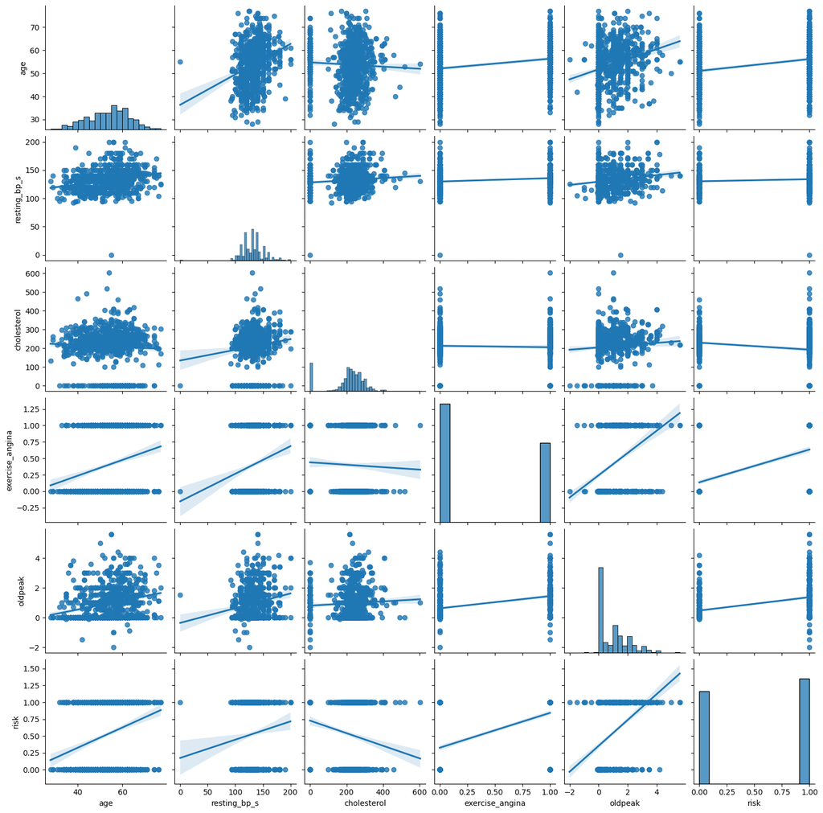

```python
# drop the first column in both datasets so it is not used in the visualisation
x_train.drop(columns=x_train.columns[0], axis=1, inplace=True)
y_train.drop(columns=y_train.columns[0], axis=1, inplace=True)

# merge the training datasets so correlations can be found in the features and their classification
merged_training = pd.merge(x_train, y_train, left_index=True, right_index=True, how = 'inner')

# drop the regession label
class_visualize = merged_training.drop('max_heart_rate', axis=1)

# plot the ditribution of features and their correlation to others
sns.pairplot(class_visualize, kind='reg')
```

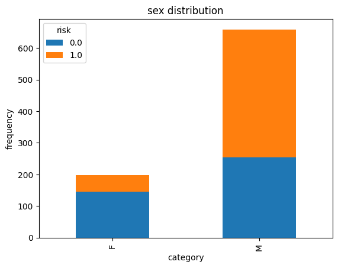

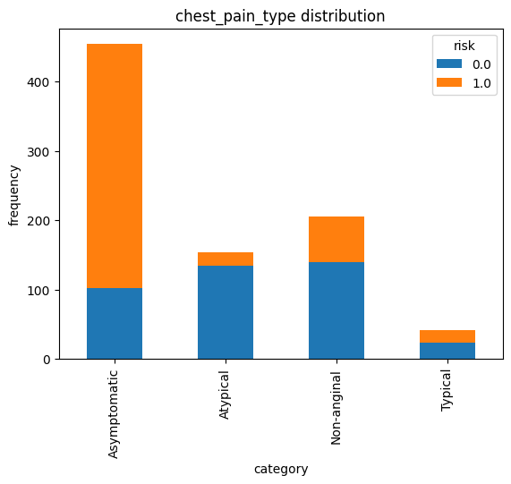

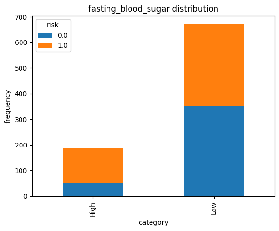

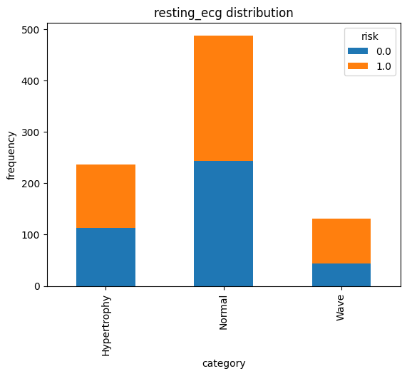

```python
# subset the categorical columns
categorical_columns = class_visualize[['sex', 'chest_pain_type', 'fasting_blood_sugar', 'resting_ecg']]

# plot a stacked bar plot to visualize the counts of each categorical feature value
# and the distribution of risk
for name, value in  categorical_columns.items():

    # create a frequency table of the categorical variable and risk
    ct = pd.crosstab(merged_training[name], merged_training['risk'])

    # plot the stacked bar plot
    ct.plot(kind='bar', stacked=True)
    plt.title(f'{name} distribution')
    plt.xlabel('category')
    plt.ylabel('frequency')
    plt.show()
```

From these charts, there are a lot more male patients than female in the dataset, with most patients having 'normal' values - normal resting ecg, low fasting blood sugar, asymptomatic chest pain. A higher proprortion of male patients are at high risk of heart disease, as well as asymptomatic chest pain patients and those with a wave type ecg. These charts will be useful when looking at feature importances and if they match up.

In order to only impute the values for cholesterol, and not other values such as oldpeak where it is normal to have a value of zero, I replace the zero values for cholesterol with missing values, also meaning they can be easily imputed. Before I pass the data to the imputation model, I must also encode the categorical data. for the columns with nominal categorical data, I use the one hot encoder, and for the ordinal data I use the ordinal encoder. I use a column transformer to preprocess all columns in one. Because exercise_angina is already in boolean form, I do not need to encode this feature.

```python
# replace the zeros in x_train with missing values
# define a function so it can be used in the pipeline at the end
def replace_zeros(x):
    x["cholesterol"] = x["cholesterol"].replace(0, np.nan)
    return x
x_train = replace_zeros(x_train)

# preprocess the data depending on the column's data type
preprocessor = ColumnTransformer(transformers =

                  # scale the continuous variables with robust scaler
                  [('mms', RobustScaler(), ['age', 'resting_bp_s', 'cholesterol', 'oldpeak']),

                  # scale the nominal variables with one hot encoder
                  ('ohe', OneHotEncoder(sparse_output = False), ['sex', 'chest_pain_type', 'resting_ecg']),

                  # scale the ordinal variables with ordinal encoder
                  ('oe', OrdinalEncoder(categories = [["Low", "High"]]), ['fasting_blood_sugar']),

                  # pass through the exercise angina columns
                  ('pt', 'passthrough', ["exercise_angina"])],
                  remainder = "drop") # drop the columns not preprocessed

# set the output for the transformers as a dataframe
preprocessor.set_output(transform = 'pandas')

# fit the transformer to the data
preprocessed_x_train = preprocessor.fit_transform(x_train)
```

There are still quite a lot of complete values for cholesterol, and the dataset is not too large, so a KNN imputer is appropriate to impute the values for cholesterol. For the imputer, I start by using the default k neighbors of 5, and visualize how this affects the data to see if the graph is similar compared to before imputation.

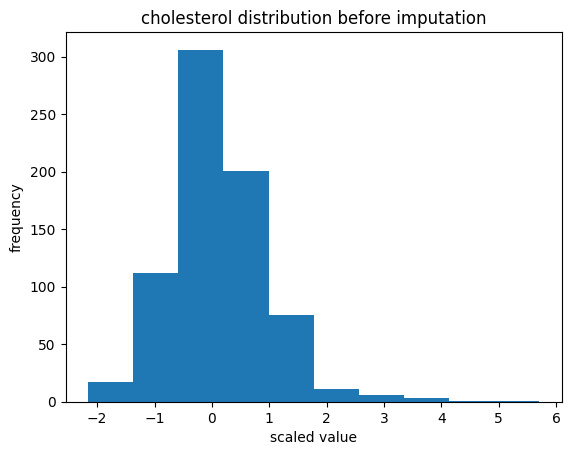

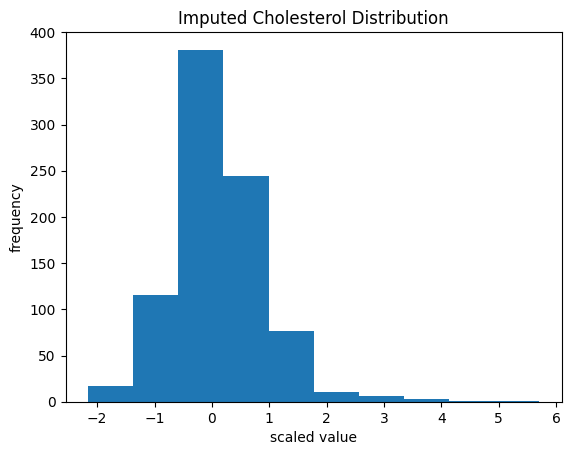

```python
# show the cholesterol distribution before imputation as a histogram
plt.hist(preprocessed_x_train['mms__cholesterol'])
plt.title('cholesterol distribution before imputation')
plt.xlabel('scaled value')
plt.ylabel('frequency')
plt.show()

# use the KNNImputer to fill in missing values
imputer = KNNImputer(missing_values=np.nan)

# set the output as a dataframe for ease of use
imputer.set_output(transform = 'pandas')

# fit the imputer to the preprocessed x_train
imputed_x_train = imputer.fit_transform(preprocessed_x_train)

# show the cholesterol distribution after imputation
plt.hist(imputed_x_train['mms__cholesterol'])
plt.title('Imputed Cholesterol Distribution')
plt.xlabel('scaled value')
plt.ylabel('frequency')
plt.show()
```

These two distributions look very similar, meaning the imputation doesn't alter the distribution too much and can be used in the model.

To reduce noise in the data, it is worth looking at the feature importances of the data to see if feature selection is useful. For this, I use a random forest model as the feature importances can easily be looked at for this model.

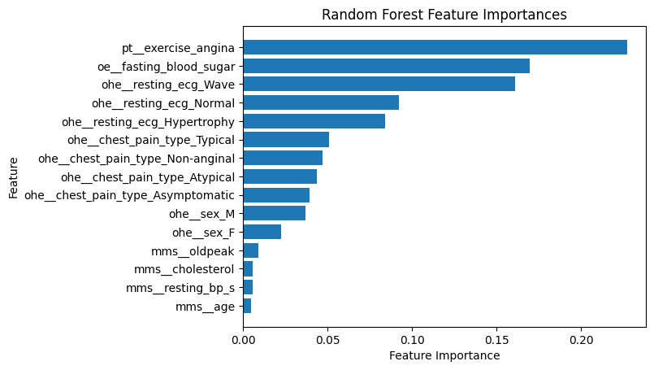

```python
# make it so that y train only contains the risk label
y_train_classification = y_train['risk']

# create a model to evaluate feature importance
importance_classifier = RandomForestClassifier(n_estimators=50, max_depth=5, random_state=1 )

#fit the model
importance_classifier.fit(imputed_x_train, y_train_classification)

#sort the model importances
importances = np.sort(importance_classifier.feature_importances_)

# plot the model importance chart
plt.barh(imputed_x_train.columns, importances)
plt.title('Random Forest Feature Importances')
plt.xlabel('Feature Importance')
plt.ylabel('Feature')
plt.show()
```

```python
# instantiate the feature selector with a random forest classifier
selector = SequentialFeatureSelector(estimator=importance_classifier,
                          n_features_to_select= 'auto',
                          direction='forward',
                          cv = 5)

selector.set_output(transform = 'pandas')
selected_x_train = selector.fit_transform(imputed_x_train, y_train_classification)

# display the list of feature names that were selected
print('columns selected:')

for column in selected_x_train.columns:
    print(column)
```

```
columns selected:
mms__resting_bp_s
mms__oldpeak
ohe__sex_F
ohe__chest_pain_type_Asymptomatic
ohe__chest_pain_type_Atypical
ohe__chest_pain_type_Non-anginal
pt__exercise_angina
```

The selected columns match values that had a significant correlation with high or low risk in the visualisations at the start, such as resting bp and asymptomatic chest pain, suggesting that the model is choosing effecting features for classification.

I now move on to model selection. In this scenario, there is the issue of interpretability vs performance. The practitioner using this model might want to know why the patient has been put in a certain risk category so that their treatment can focus on the factors causing the classification. On the other hand, using less interpretable models such as ensemble models will likely be better at predicting the risk. For this reason I will try both individual and ensemble models. From the exploratory data analysis I did at the start, There is some covariance in the features, so the model needs to be effective at handling this. For binary classification, tree based models and logistic regression allow for some covariance. A voting based model can also do this by correcting the weaknesses in each model.

```python
# specify the classifiers for the voting model
svc = SVC(random_state=1)
dtc = DecisionTreeClassifier(random_state=1)
lr_vote = LogisticRegression(random_state=1)

# list the voting classifiers as tuples to pass to the voting classifier
voting_classifiers = [('SVC', svc), ('decision_tree', dtc), ('logistic_regression', lr_vote)]

# list the voting classifiers on their own for the grid search
voting_list = [svc, dtc, lr_vote]


# specify the classifiers as potentials for the final model
rfc = RandomForestClassifier(random_state=1)
lr_individual = LogisticRegression(random_state=1)
vc = VotingClassifier(estimators=voting_classifiers)
classifiers =[rfc, lr_individual, vc]
```

Next I tune the hyperparameters for each model using a grid search. In order to do this for the voting model, I first search the models individually then search for the model as a whole. For this model, it is important not to miss patients with a high risk of cardiovascular disease, therefore the priority should be on the model having a high recall, as well as the model accurately classifying patients. This is a factor I will consider when choosing the final model.

```python
# for each of the models in the voting classifier
voting_param_grid = [

{ # for the svc model
    'C': [0.1, 1, 10, 20],
	'gamma': [1, 0.1, 0.01, 0.001, 0.0001],
	'kernel': ['rbf']
},
{  # for the decision tree model
    'max_depth': [2,5,7,10],
    'min_samples_split': [2, 5, 10],
    'min_samples_leaf': [1, 2, 3]
},
{ # for the logistic regression model
    'penalty':['l1','l2'],
    'C' : np.logspace(-4,4,20),
    'solver': ['liblinear'],
    'max_iter'  : [100,1000,2500,5000]
}
]

# preprocess, impute and select the validation set so it can be used to score the model
transforming_pipeline = make_pipeline(FunctionTransformer(replace_zeros),
                                      preprocessor,
                                      imputer,
                                      selector)
transformed_x_val = transforming_pipeline.transform(x_val)

# subset the y validation data to only include the classification label
y_val_categorical = y_val['risk']

# do the grid search as a function so I can use it later
def grid_search(classifiers, param_grid, scoring):

    # set an index that chooses the parameters from the voting param grid
    i = 0

    # search for the best hyperparameters for each model
    for classifier in classifiers:
        searcher = GridSearchCV(
                                estimator=classifier,
                                param_grid=param_grid[i],
                                scoring = [scoring],
                                n_jobs=-1,
                                refit=scoring,
                                cv = 5
                                )

        # fit the grid search to the data and put the model with the best hyperparameters into a variable
        tuned_classifier = searcher.fit(selected_x_train, y_train_classification)

        # display the name of the model
        print(f'classifier: {classifier}')

        # display the best parameters for the scoring used
        print(f'best hyperparameters: {tuned_classifier.best_params_}')

        y_predict = tuned_classifier.predict(transformed_x_val)

        # show the precision, accuracy and recall for the model based on the validation set
        print('model scores:')
        print(classification_report(y_val_categorical, y_predict))

        print('-' * 70)

        # change to the next parameter grid for the next grid search
        i += 1

grid_search(voting_list, voting_param_grid, scoring = 'accuracy')

# update the models for the voting classifier
voting_classifiers = [('SVC',SVC(C = 10, gamma=1, kernel='rbf', random_state=1, probability=True)),
                 ('decision_tree', DecisionTreeClassifier(max_depth=7, min_samples_leaf=1, min_samples_split = 2, random_state=1)),
                 ('logistic_regression', LogisticRegression(C = np.float64(0.23357214690901212), max_iter=100, penalty='l2', solver = 'liblinear', random_state=1))]
```

```
classifier: SVC(random_state=1)
best hyperparameters: {'C': 10, 'gamma': 1, 'kernel': 'rbf'}
model scores:
              precision    recall  f1-score   support

         0.0       0.80      0.78      0.79       102
         1.0       0.81      0.82      0.81       112

    accuracy                           0.80       214
   macro avg       0.80      0.80      0.80       214
weighted avg       0.80      0.80      0.80       214

----------------------------------------------------------------------
classifier: DecisionTreeClassifier(random_state=1)
best hyperparameters: {'max_depth': 7, 'min_samples_leaf': 1, 'min_samples_split': 2}
model scores:
              precision    recall  f1-score   support

         0.0       0.74      0.87      0.80       102
         1.0       0.86      0.72      0.79       112

    accuracy                           0.79       214
   macro avg       0.80      0.80      0.79       214
weighted avg       0.80      0.79      0.79       214

----------------------------------------------------------------------
classifier: LogisticRegression(random_state=1)
best hyperparameters: {'C': np.float64(0.23357214690901212), 'max_iter': 100, 'penalty': 'l2', 'solver': 'liblinear'}
model scores:
              precision    recall  f1-score   support

         0.0       0.84      0.76      0.80       102
         1.0       0.80      0.87      0.83       112

    accuracy                           0.82       214
   macro avg       0.82      0.82      0.82       214
weighted avg       0.82      0.82      0.82       214

----------------------------------------------------------------------
```

```python
# set the values of hyperparameters to search
classifiers_param_grid = [{
    # for the random forest model
    'n_estimators': [50, 100, 150, 200],
    'max_depth': [2, 3, 4, 5, 6],
    'max_features': ['sqrt', 'log2', None],
    'bootstrap': [True, False],
    'random_state': [1]
},
{  # for the logistic regression model
    'penalty':['l1','l2'],
    'C' : np.linspace(0.0001, 10,20),
    # I have chosen this solver because it is better for smaller datasets
    'solver': ['liblinear']
},
{ # for the voting classifier
    'voting':['hard', 'soft'],
    'weights':[[1,2,3],[2,1,3],[3,2,1]],
}
]

# tune the hyperparameters for the models and get the results
grid_search(classifiers, classifiers_param_grid, scoring = 'accuracy')
```

```
classifier: RandomForestClassifier(random_state=1)
best hyperparameters: {'bootstrap': True, 'max_depth': 6, 'max_features': 'sqrt', 'n_estimators': 100, 'random_state': 1}
model scores:
              precision    recall  f1-score   support

         0.0       0.84      0.81      0.83       102
         1.0       0.83      0.86      0.85       112

    accuracy                           0.84       214
   macro avg       0.84      0.84      0.84       214
weighted avg       0.84      0.84      0.84       214

----------------------------------------------------------------------
classifier: LogisticRegression(random_state=1)
best hyperparameters: {'C': np.float64(0.5264105263157894), 'penalty': 'l2', 'solver': 'liblinear'}
model scores:
              precision    recall  f1-score   support

         0.0       0.84      0.76      0.80       102
         1.0       0.80      0.87      0.83       112

    accuracy                           0.82       214
   macro avg       0.82      0.82      0.82       214
weighted avg       0.82      0.82      0.82       214

----------------------------------------------------------------------
classifier: VotingClassifier(estimators=[('SVC', SVC(random_state=1)),
                             ('decision_tree',
                              DecisionTreeClassifier(random_state=1)),
                             ('logistic_regression',
                              LogisticRegression(random_state=1))])
best hyperparameters: {'voting': 'hard', 'weights': [3, 2, 1]}
model scores:
              precision    recall  f1-score   support

         0.0       0.82      0.77      0.80       102
         1.0       0.81      0.85      0.83       112

    accuracy                           0.81       214
   macro avg       0.81      0.81      0.81       214
weighted avg       0.81      0.81      0.81       214

----------------------------------------------------------------------
```

In this case, the random forest model is the best at balancing recall and accuracy, so I will use this one going forward. To look at overfitting and underfitting, I look at the learning curves for each of the models. While this model is not as interpretable, explainable AI packages could be used to find out how the model came to its decision.

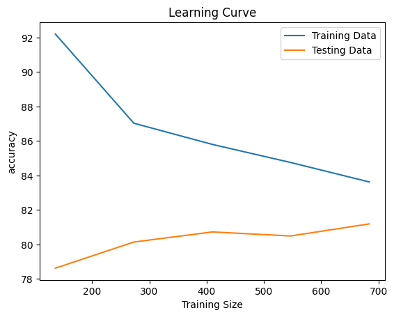

```python
# update the models with the best hyperparameters
classifier_best = RandomForestClassifier(bootstrap=True,
                                        max_depth =  4, # reduced max depth
                                        max_features= 6,
                                        # reduced max features based on the feature importances seen earlier
                                        n_estimators = 200, # increased the number of trees
                                        random_state=1)


# plot a learning curve for each of the classifiers
# create a function that can be used in the regression task
def plot_learning_curve(model, scoring):
    lc = learning_curve(model,
                        selected_x_train,
                        y_train_classification,
                        train_sizes=np.array([0.2, 0.4, 0.6, 0.8, 1.0]),
                        cv = 5,
                        scoring = scoring,
                        shuffle = True,
                        random_state = 1)

    plt.plot(lc[0], (lc[1].mean(axis=1) * 100))
    plt.plot(lc[0], (lc[2].mean(axis=1) * 100))
    plt.title('Learning Curve')
    plt.legend(['Training Data', 'Testing Data'])
    plt.xlabel('Training Size')
    plt.ylabel(scoring)
    plt.show()

plot_learning_curve(classifier_best, 'accuracy')
```

The gap between the training and testing sets was slightly large initially, suggesting overfitting. I reduced max depth and max features, and increased the number of trees to reduce the overfitting. Now that the model is tweaked, the training and testing sets converge, with the testing data set rising more in accuracy. The model can be put all together in a pipeline.

```python
# make the model pipeline
#use function transformer so the replace zeros function is used in the pipeline
model = make_pipeline(FunctionTransformer(replace_zeros),
                      preprocessor,
                      imputer,
                      selector,
                      classifier_best)

# test on the validation set
model.fit(x_train, y_train_classification)
y_predict = model.predict(x_val)
print(classification_report(y_val_categorical, y_predict))
```

```
              precision    recall  f1-score   support

         0.0       0.86      0.78      0.82       102
         1.0       0.82      0.88      0.85       112

    accuracy                           0.84       214
   macro avg       0.84      0.83      0.84       214
weighted avg       0.84      0.84      0.84       214
```

As a final note, I am unsure if the y_test.csv only contains the column lablel 'risk', or the other two columns as well. If it contains all of them, the 'risk' column will need to be subsetted before passing y_test to the model.

#### **You will not be able to run the code below as you do not have access to `x_test.csv` and `y_test.csv`.**

This code will load the hidden testing data from `x_test.csv` and `y_test.csv`, predict the class label using your model (assuming your model is assigned to the variable name `model`; **change the code below if you have used a different name!**), and evaluate the final model performance against the values in `y_test.csv` using the accuracy. Your performance on the hidden testing data is a graded component of the assessment.

Ensure that your final chosen model is complete, fit, and ready to predict after running the last block of code, as the block below will be run afterwards and is expected to run without error.

#### **You will not be able to run the code below as you do not have access to `x_test.csv` and `y_test.csv`.**

```python
# YOU WILL NOT BE ABLE TO RUN THIS CODE!

from sklearn.metrics import accuracy_score

x_test = np.genfromtxt('x_test.csv', delimiter = ',')
y_test = np.genfromtxt('y_test.csv', delimiter = ',')

y_predict = model.predict(x_test)

accuracy = accuracy_score(y_test, y_predict)

print(f'Final Accuracy: {accuracy:.6f}')
```

[output not shown]

### Task 02: Regression

Build and fit a regression model to predict a patient's maximum heart rate (`max_heart_rate` in `y_train.csv`) using the feature vectors in `x_train.csv` as the input. Evaluate your regression model using the mean absolute error (MAE), and optimise the hyperparameters of your regression model to obtain the best performance possible on unseen data.

You can use any regression model implemented in Scikit-Learn; you are not restricted to models that we have discussed in the lectures and associated workshops. Show evidence that you have:

- appropriately pre-processed your features.
- considered more than one regression model.
- optimised the hyperparameters of your chosen regression model.
- evaluated your chosen regression model on held-out data.

First I explore the data to see the correlations between features and the labels.

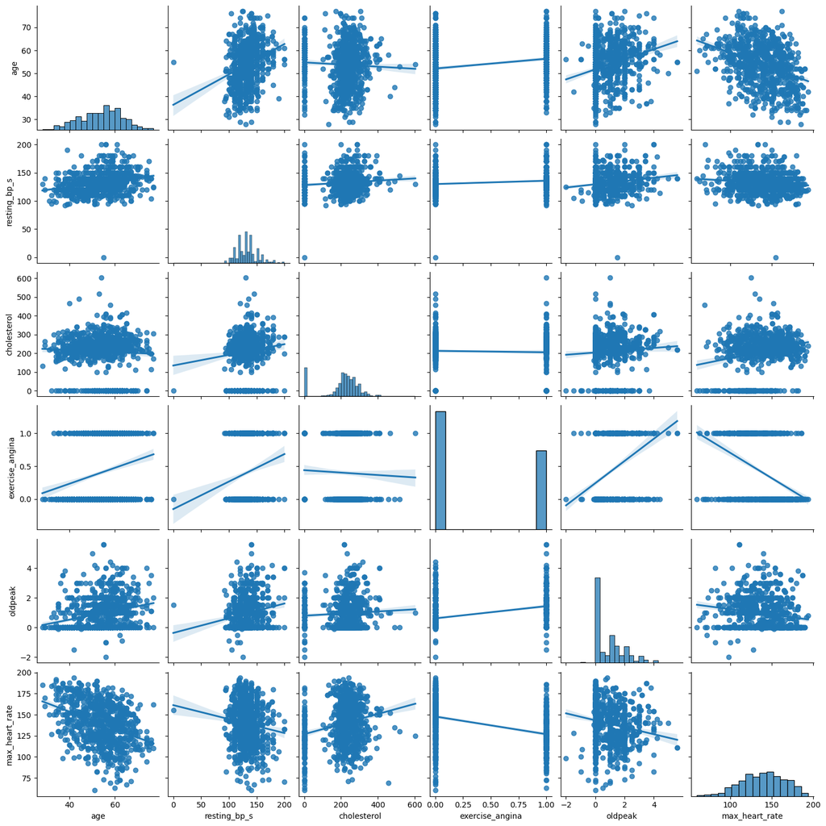

```python
# dropped the 'risk' column so only the max_heart_rate label is seen
reg_visualize = merged_training.drop('risk', axis=1)

# plot the pair plot
sns.pairplot(reg_visualize, kind='reg')
```

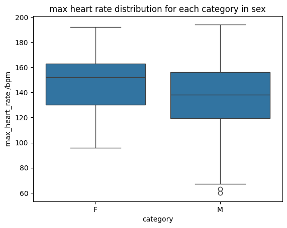

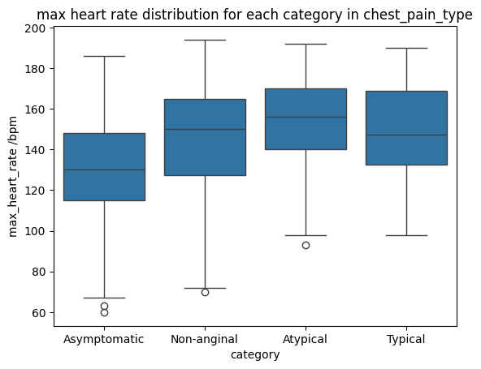

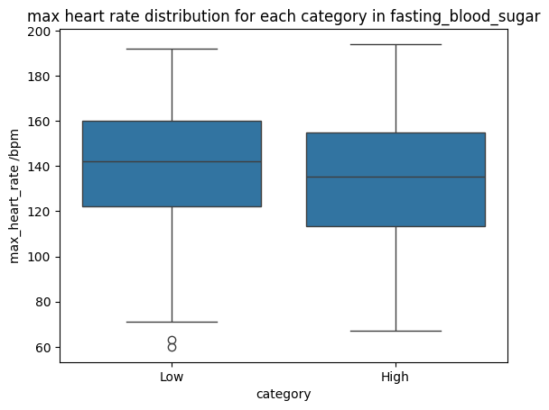

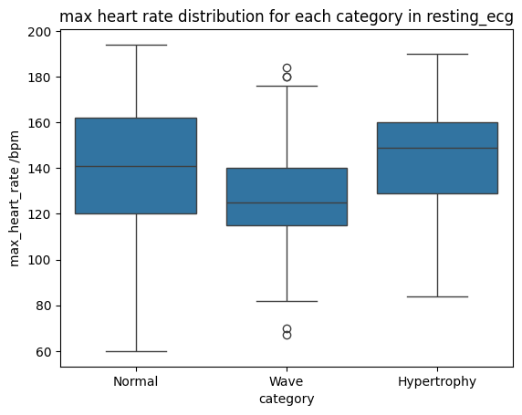

```python
# plot a box plot to visualize the distribution of max_heart_rate
# for each category in the categorical variables
for name, value in categorical_columns.items():

    # create a frequency table of the categorical variable and risk
    sns.boxplot(x=name, y='max_heart_rate', data=merged_training)

    # plot the stacked bar plot
    plt.title(f'max heart rate distribution for each category in {name}')
    plt.xlabel('category')
    plt.ylabel('max_heart_rate /bpm')
    plt.show()
```

These data show that average max heart rate is higher in women and higher in those with low fasting blood sugar.

Because the training dataset is the same for this regression problem, I can use the same preprocessing as for the classification problem, so I move straight on to feature selection, first looking at the feature importances.

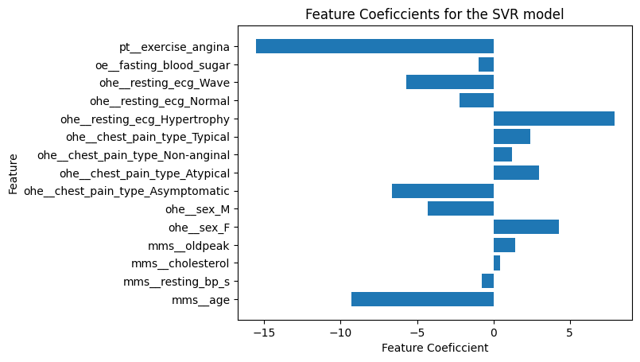

```python
# separate the y_train and y_test sets into purely the regression label data
y_train_regression = y_train['max_heart_rate']
y_val_regression = y_val['max_heart_rate']

# use a linear SVR to look at feature importances
selector_model = SVR(C = 10, kernel='linear')

# fit the model
selector_model.fit(imputed_x_train, y_train_regression)

# plot feature importance using model coefficients
plt.barh(imputed_x_train.columns, selector_model.coef_.flatten())
plt.title('Feature Coeficcients for the SVR model')
plt.xlabel('Feature Coeficcient')
plt.ylabel('Feature')
plt.show()
```

I use these feature importances to estimate that selecting 7 features will remove noise from the data. I use the wrapper method of recursive feature elimination to improve model performance.

```python
# create and fit the feature selector
selector = RFE(selector_model, n_features_to_select=7)
selector.set_output(transform = 'pandas')
selected_x_train = selector.fit_transform(imputed_x_train, y_train_regression)

# print out the selected columns
print('selected columns:')
for column in selected_x_train.columns:
    print(column)
```

```
selected columns:
mms__age
ohe__sex_F
ohe__sex_M
ohe__chest_pain_type_Asymptomatic
ohe__resting_ecg_Hypertrophy
ohe__resting_ecg_Wave
pt__exercise_angina
```

I initially only used the selected data on the linear regression and SVR, as the other two models use their own form of feature selection, however I found it improved the other two models to use the selected data as well. I chose linear regression for comparison, ridge regression as it handles covarying features well, and random forest and SVR in case the relationships between the features and max_heart rate were non linear.

```python
# specify the regressors to use
regressors = {
    'linear_regression':LinearRegression(),
    'random_forest_regressor':RandomForestRegressor(),
    'ridge_regression':Ridge(),
    'SVR':SVR()
}
```

I then moved on to hyperparameter tuning. As this is a regression problem, the main goal is to reduce the error, so I focused the search on this.

```python
# specify the parameters to search
param_grid = [{},
              {
                'n_estimators' : [50, 100, 150, 200, 250],
                'max_depth' : [2,3,4,5,6],
                'random_state': [1]
              },
              {
                  'alpha' : [0.05, 0.1, 0.2, 0.5, 1.],
                  'random_state': [1]
              },
              {
                  'C' : np.linspace(0.0001, 15,20),
              }]

# create an index to relate to the parameter grid to use
i = 0

# grid search for each of the regressors to find the one with the negative mean absolute error closest to zero
for regressor in regressors:
    searcher = GridSearchCV(estimator = regressors[regressor], param_grid=param_grid[i], scoring='neg_mean_absolute_error')
    searcher.fit(selected_x_train, y_train_regression)

    # move on to the next parameter grid
    i += 1

    # print the model name, best parameters and associated neg mean absolute error
    print(f'model: {regressor}')
    print(f'best hyperparameters: {searcher.best_params_}')
    tuned_model = searcher.best_estimator_
    print(f'best negative mean absolute error: {searcher.best_score_}')
    print('-' * 30)
```

```
model: linear_regression
best hyperparameters: {}
best negative mean absolute error: -17.014647949933668
------------------------------
model: random_forest_regressor
best hyperparameters: {'max_depth': 6, 'n_estimators': 150, 'random_state': 1}
best negative mean absolute error: -16.88961714045401
------------------------------
model: ridge_regression
best hyperparameters: {'alpha': 0.05, 'random_state': 1}
best negative mean absolute error: -17.014743548886724
------------------------------
model: SVR
best hyperparameters: {'C': np.float64(5.526378947368421)}
best negative mean absolute error: -16.545473317451222
------------------------------
```

The model with the best score is the SVR, potentially because some of the data is nonlinear, which is supported by the random forest also doing well. I move forward with this model and look at overfitting and underfitting

[figure not shown]

```python
# specify the final hyperparameters of the SVR model
best_regressor = SVR(C = np.float64(5.5))

# plot the learning curve of the model using the function defined previously
plot_learning_curve(best_regressor, 'neg_mean_absolute_error')
```

Changing the C beyond the best value from the grid search has diminishing returns on changing the learning curve, so I keep the value of C roughly as it is, especially as the training and testing sets are close together in the graph. I now specify the final model using this regressor.

```python
# make the final model pipeline
model = make_pipeline(FunctionTransformer(replace_zeros),
                      preprocessor,
                      imputer,
                      selector,
                      best_regressor)

# fit the model
model.fit(x_train, y_train_regression)

# predict the mean absolute error when testing the validation set
y_predict = model.predict(x_val)
print(f'model mean absolute error: {mean_absolute_error(y_val_regression, y_predict)}')
```

```
model mean absolute error: 16.894149567374992
```

#### **You will not be able to run the code below as you do not have access to `x_test.csv` and `y_test.csv`.**

This code will load the hidden testing data from `x_test.csv` and `y_test.csv`, predict the class label using your model (assuming your model is assigned to the variable name `model`; **change the code below if you have used a different name!**), and evaluate the final model performance against the values in `y_test.csv` using the accuracy. Your performance on the hidden testing data is a graded component of the assessment.

Ensure that your final chosen model is complete, fit, and ready to predict after running the last block of code, as the block below will be run afterwards and is expected to run without error.

#### **You will not be able to run the code below as you do not have access to `x_test.csv` and `y_test.csv`.**

```python
# YOU WILL NOT BE ABLE TO RUN THIS CODE!

from sklearn.metrics import mean_absolute_error

x_test = np.genfromtxt('x_test.csv', delimiter = ',')
y_test = np.genfromtxt('y_test.csv', delimiter = ',')

y_predict = model.predict(x_test)

mae = mean_absolute_error(y_test, y_predict)

print(f'Final MAE: {mae:.6f}')
```

[output not shown]